## Overview

Concordance analysis allows us to group strains that are genetically almost identical into an isotype. The following table summarizes the number of isotypes from previous and current releases, and the number of strains that belong to those isotypes.

|  | **Isotypes** | **Strains Included** | **Strains with WGS data** | **Strains with RAD-seq data** |
| --- | --- | --- | --- | --- |
| **Isotypes from Previous Release** | 400* | 910 | 770 | 140 |
| **New Isotypes from Current Release** | 140 | 468 | 468 | 0 |
| **Total** | 540 | 1378 | 1238 | 140 |

*Four strains were reduced to a single isotype group so this number was reduced from 403 to 400 (see below for details)

## Concordance score distribution and cutoff

We examined the pairwise concordance scores of all strains. Concordance values for every pair of strains were calculated as the number of shared variant sites divided by the total number of variants called for each pair. If the concordance score was more than 0.9997, the strain pair is grouped into the same isotype.

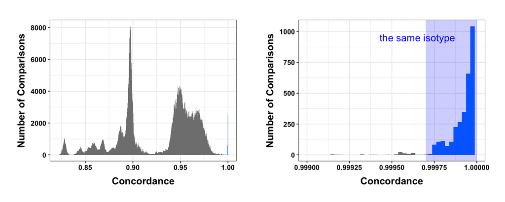

## Search for concordance for strain pairs

Strain comparisons are listed in the table below. Only concordance scores > 0.999 are shown.

| Strain | Strain | Total variants | Diff variants | Concordance | Is isotype |
| --- | --- | --- | --- | --- | --- |
| BRC20113 | BRC20067 | 2828827 | 70 | 0.999975254761072 | True |
| ECA1071 | ECA1070 | 2838267 | 90 | 0.999968290509667 | True |
| ECA1072 | ECA1070 | 2819033 | 80 | 0.999971621474456 | True |
| ECA1072 | ECA1071 | 2851166 | 80 | 0.999971941304014 | True |
| ECA1073 | ECA1070 | 2830598 | 61 | 0.999978449783403 | True |
| ECA1073 | ECA1071 | 2862988 | 66 | 0.999976947161497 | True |
| ECA1073 | ECA1072 | 2844076 | 52 | 0.9999817163817 | True |
| ECA1074 | ECA1070 | 2838826 | 94 | 0.999966887720487 | True |
| ECA1074 | ECA1071 | 2873147 | 52 | 0.999981901378523 | True |
| ECA1074 | ECA1072 | 2851121 | 85 | 0.999970187164978 | True |

[output cut: 3141 more lines]

- ECA2649 had high concordance to two distinct isotype groups. However, upon investigating the relationships to each group, we chose to manually place ECA2649 with isotype ECA2551, not ECA2672.

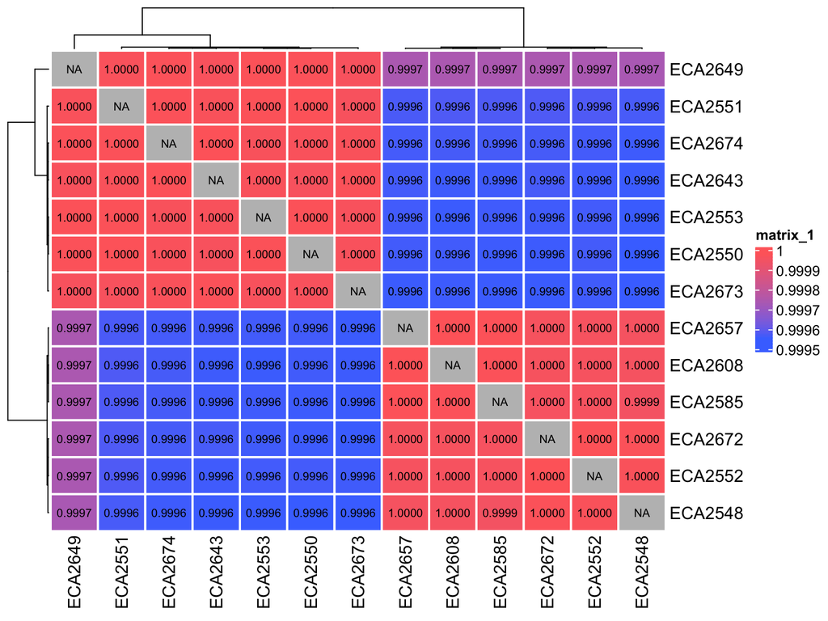

## Changes from previous release

- This release used only SNVs for isotype assignment.
- Four strains (ECA2677, ECA2678, ECA2679, and ECA2686) were removed because they were frozen as “dirty” strains and have now been cleaned, frozen, and re-sequenced. Because these four strains were isotype reference strains, a new isotype reference strain was assigned. It appears that the other six strains in these isotype groups changed isotypes, but they remain in the same group as before with a new, clean isotype reference strain. Details can be found below.

[output not shown]

*Clean strain for ECA2686 is ECA2803 but has not been sequenced yet.

- Strains ECA1465, ECA1467, ECA1493, ECA1515 were each their own isotype in 20200815 release. They were grouped into the same isotype in this release, which resulted in a reduce of count of previous isotypes from 403 to 400. Below is their pairwise concordance value in this release (top) and in 20200815 release (bottom).

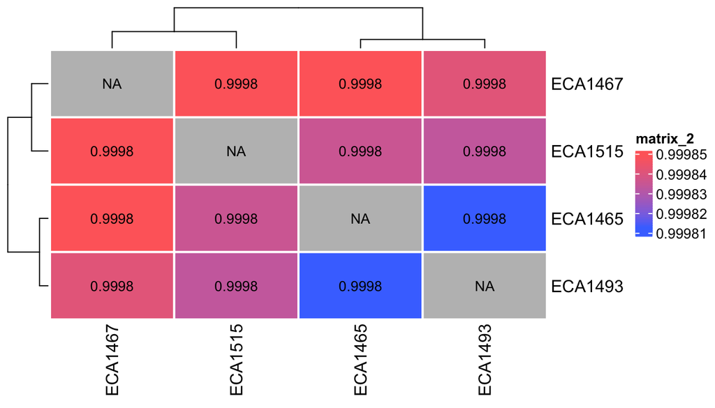

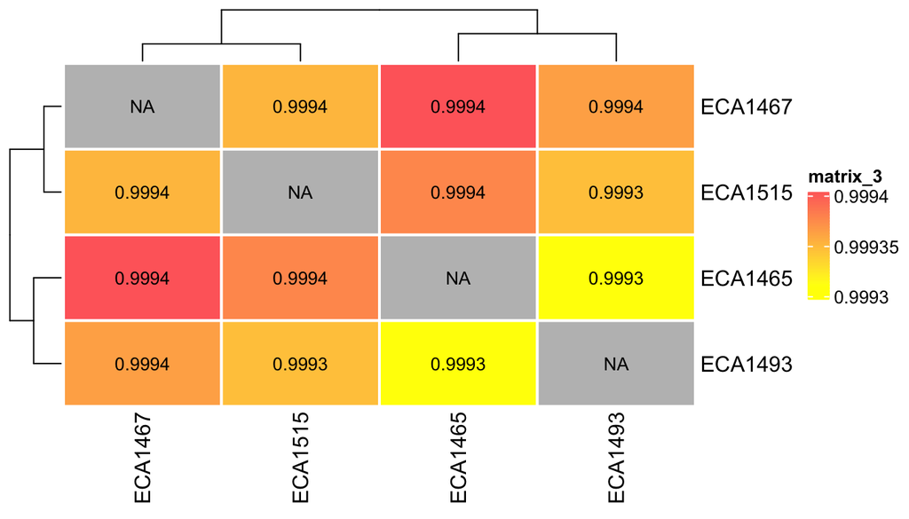